# Midpoint Deliverable

Kai Jeffreys

11/30/2020

## Introduction

For this assignment, we are using the NHIS Data set. The data was collected through personal household interviews, where participants are asked a series of questions about their personal health, including their heart. Data was collected by the NHIS, a branch of the CDC. The data shows the proportion of the people who surveyed had cardiovascular disease, among other risk factors, within in a certain subset of the overall population of people surveyed. The proportion is shown in the Data_Value column as a percent. The data is sorted into breakout groups, like age, gender, or race. Since the breakout groups are all in one column, it is hard to make an easy summary of the data, since there is so much overlapping. It also has different columns for year and location, so there are more ways to break down the data other than the breakout groups.

## Summary Information

Since **36.0511705**% of American’s are at risk of cardiovascular diseases and **5.7207565** % have cardiovascular diseases, heart issues are a top health concern. **Hypertension** is the most prevalent risk and **Major Cardiovascular Disease** the most prevalent cardiovascular disease. Between 2000 and 2012 both risk and cardiovascular diseases peeked in **2008**. The housing market crashing then increased stress levels and would have influenced risks and diseases peeking.

## Summary Table

| Condition | Gender | Percent |
| --- | --- | --- |
| Hypertension | Female | 94.783333 |
| Hypertension | Male | 90.100000 |
| Physical Inactivity | Female | 34.785556 |
| Physical Inactivity | Male | 30.397778 |
| Smoking | Male | 21.509444 |
| Smoking | Female | 17.059444 |
| Major Cardiovascular Disease | Male | 8.960000 |
| Major Cardiovascular Disease | Female | 6.416667 |
| Coronary Heart Disease | Male | 5.442222 |
| Acute Myocardial Infarction (Heart Attack) | Male | 4.223889 |
| Coronary Heart Disease | Female | 2.975000 |
| Stroke | Male | 2.510556 |
| Stroke | Female | 2.497778 |
| Acute Myocardial Infarction (Heart Attack) | Female | 2.125556 |

The breakout column had three dimensions: age, gender, and race. We picked gender, so we didn’t have overlays with the data values. Males tend to have a higher average percent of cardiovascular diseases than females except for the most prevalent one, hypertension. Females also report a higher percent of inactivity, but a lower percent of smoking. Males have almost double acute myocardial infarction (heart attack) than females. The other cardiovascular disease that males and females have significant differences in is coronary heart disease. This makes sense since a complete blockage from coronary heart disease can lead to a heart attack.

## Cardiovascular Disease and Race

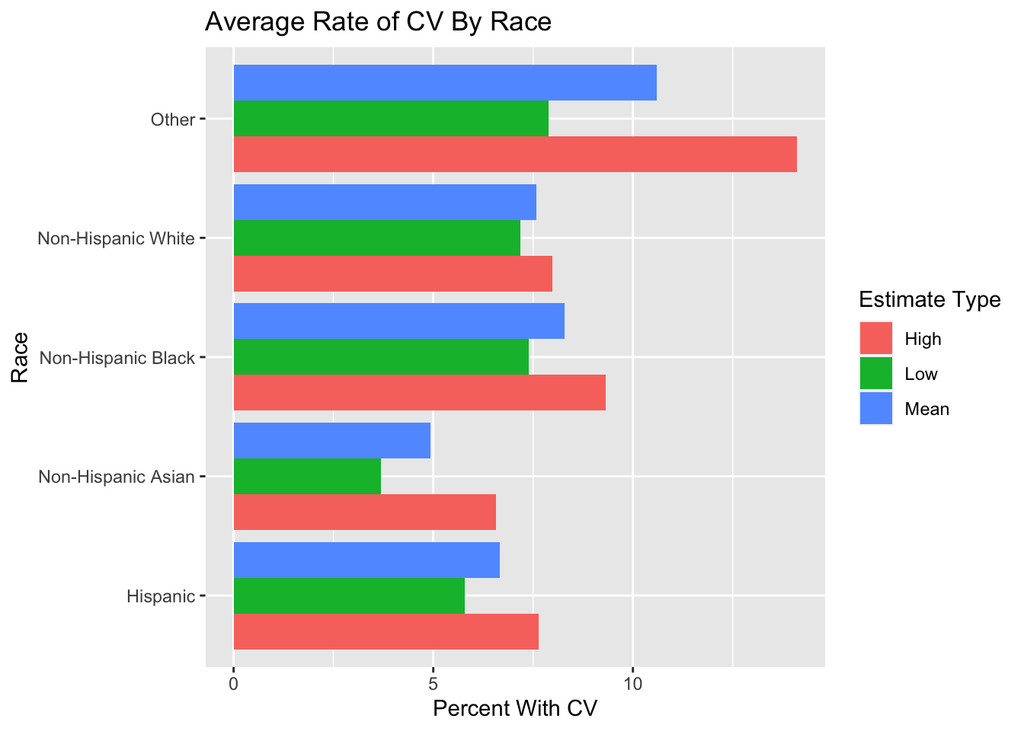

This bar chart helps show a relationship between race and the chance of having major cardiovascular disease in the entirety of the US. Along with showing the mean, the chart also shows the average low and high estimates. This is because showing just the mean might not be entirely reliable, but having the low and high estimates show the range where the true average percent of each race should lie.

## Risk Factors Comparison

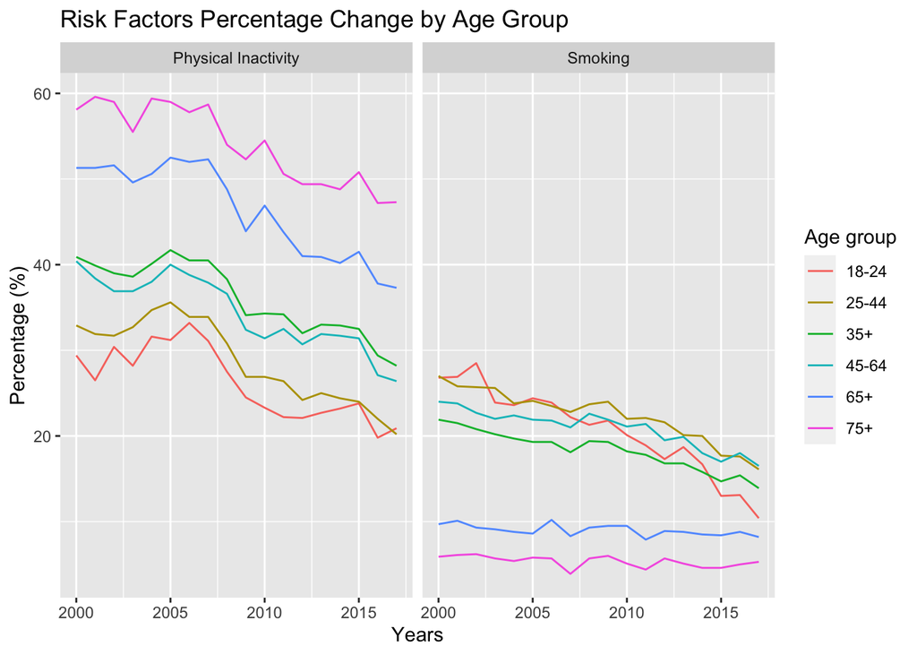

This chart shows the relationships between the year and the percent of people who have or have used particular risk factors for cardiovascular disease. The chart also breaks the data down for separate age groups.

The chart shows:

- The percent of people decreases for both being physically inactive and smoking as time goes on as we see the percent decreasing as the years get larger
- The older a person gets, the more likely they are to be physically inactive, since the lines that include more elder people are the ones that are shown to have a higher percent
- The younger a person gets, the more likely the are to smoke, since the colors that include the young adults have higher percentages of smoking

## Cardiovascular Diseases by Age and Region

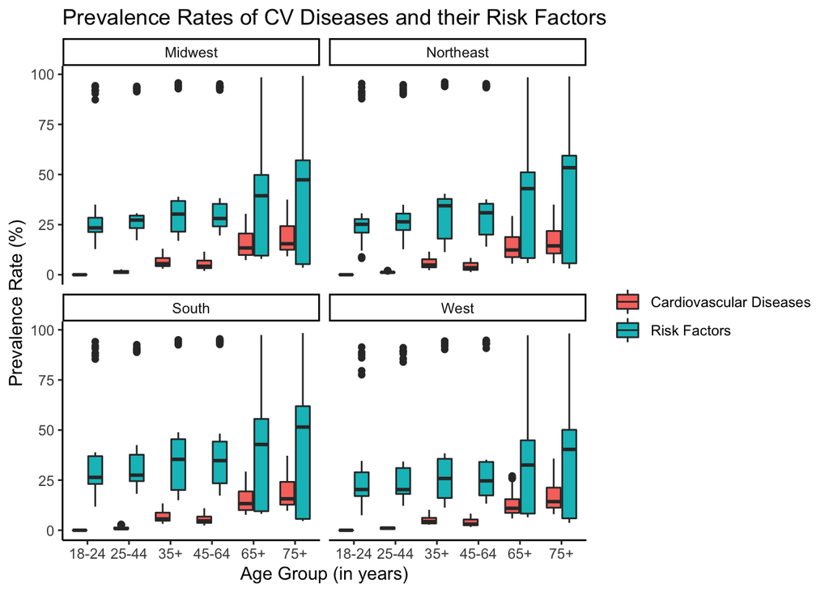

This attempts to understand the relationships between age, CV risk factors and the prevalence of CV Disease. It also attempts to see if these variables are related differently in various geographical regions of the US from the years 2000 to 2017.

Insights from the data include:

- Regardless of age or region, people, medially, acquire cardiovascular (CV) diseases at a smaller rate than people exhibit the risk factors (low physical activity and smoking) in the US.
- Older people correspond to a higher prevalence of CV risk factors and CV diseases in the US.
- The prevalence of CV risk factors before 64 years has q distribution with outlying data points, but after 64 years, the data is more spread out with more higher prevalence rates in the 4rd inter-quartile range of the box plots. This is consistent with the jump in prevalence of CV diseases after 64 years of age. This strong correlation may be due to 64 being the retirement age in US.
- There are no significant differences in CV risk factors or diseases between various regions of the US.